# 第2回 線形回帰で学ぶ汎化性能とリークの再現

その式はまだ来ていない日にも当たるか

# 導入

## 場面：自転車シェア

① 場面●○

- あなたは、自転車シェアの運営者
- 毎晩、明日に向けて自転車を何台用意するかを決める

## 決めたいこと

① 場面●●

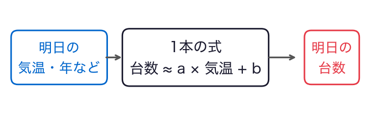

- 明日の気温などを入れると、台数が出てくる1本の式がほしい
- その式が、まだ来ていない日にどれだけ当たるかも知りたい

## 手元のデータ

② 手元のデータ●○○

- ある自転車シェアの731日の記録（2011年1月1日〜2012年12月31日）
- 1行が1日。行は日付の順に、過去から未来へ並ぶ
- 毎晩当てたかったのは、その日の台数

## データをのぞく

② 手元のデータ●●○

|  | 日付 | 季節 | 年 | 天気 | 気温 | 一般客 | 会員 | 台数 |
| --- | --- | --- | --- | --- | --- | --- | --- | --- |
| 0 | 2011-01-01 | 1 | 0 | 2 | 0.344167 | 331 | 654 | 985 |
| 1 | 2011-01-02 | 1 | 0 | 2 | 0.363478 | 131 | 670 | 801 |
| 2 | 2011-01-03 | 1 | 0 | 1 | 0.196364 | 120 | 1229 | 1349 |
| 3 | 2011-01-04 | 1 | 0 | 1 | 0.200000 | 108 | 1454 | 1562 |
| 4 | 2011-01-05 | 1 | 0 | 1 | 0.226957 | 82 | 1518 | 1600 |

- 季節（1〜4の番号）、年（0が2011年）、天気（1が晴れ）、気温（0〜1に縮めた値）

## 散布図で分かること

② 手元のデータ●●●

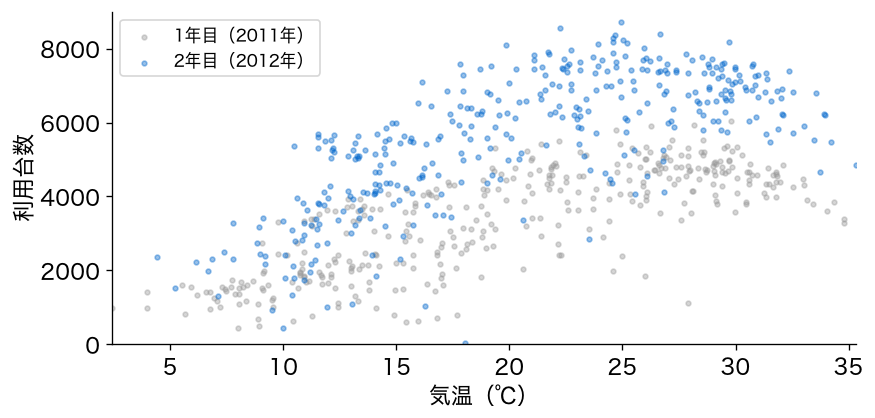

- 暖かいほど多いが、暑すぎると頭打ち。同じ気温でも2年目（青）のほうが多い

## まず思いつく答え：似た日の平均

③ 似た日の平均●○○

- 「明日何台？」に、条件が似た日の平均で答えてみる
- 外れ幅（実際と答えの差の大きさの平均）は、毎日同じ平均なら1582台、気温帯×年で762台

## でも答えはガタガタの段

③ 似た日の平均●●○

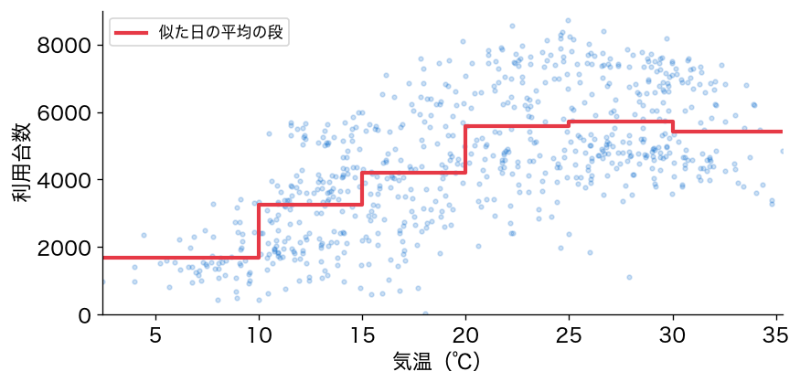

- 24.9℃と25.1℃で、答えが跳ぶ

## しかも採点が甘い

③ 似た日の平均●●●

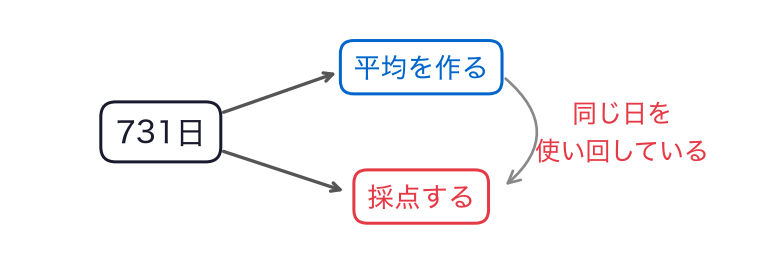

- 細かく分けるほど外れ幅は縮む（408台まで）。でも、作るのに使った日で採点している

## 気になる列①：一般客と会員

④ 気になる2つの列●○

```
   一般客    会員    台数
0  331   654   985
1  131   670   801
2  120  1229  1349

一般客＋会員＝台数の日: 731 日
```

- 一般客と会員を足すと、731日すべてで、ちょうど台数になる
- 明日の一般客と会員の数は、明日が来るまで分からない

## 気になる列②：日付

④ 気になる2つの列●●

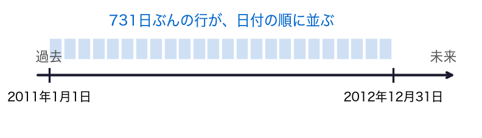

- 明日を当てたいのに、未来の日を見て学んでいないか？
- この2つの列には、今日の後半で戻ってくる

## 最後に出す答え

⑤ 今日の問い●○○○○

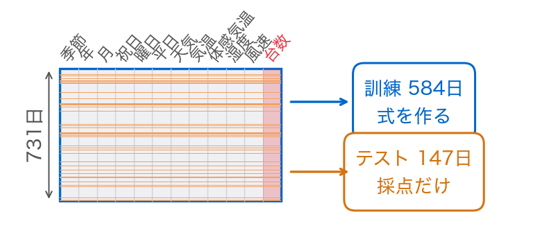

- 式を作るのに使わなかった日で測った当たり具合と、明日の台数

## 今日の問い

⑤ 今日の問い●●○○○

段を、1本の式にしたい。その式は、まだ来ていない日にも当たるのか？

## もう1つのねらい：式をコードに

⑤ 今日の問い●●●○○

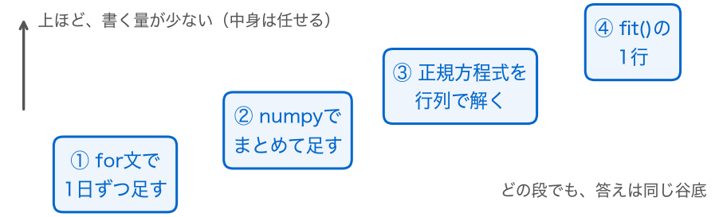

- 式の記号を、コードに1対1で写せるようになる
- そのために、便利な`fit()`の前に、1日ぶんの計算から自分で書く

## 同じ計算を4つの書き方で

⑤ 今日の問い●●●●○

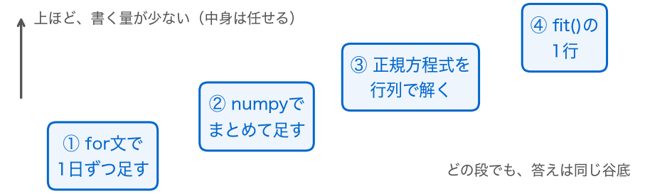

- ①`for`文で1日ずつ → ②numpyでまとめて → ③正規方程式 → ④`fit()`の1行
- 4つとも同じ答えになることを、確かめながら進む

## 今日の道筋

⑤ 今日の問い●●●●●

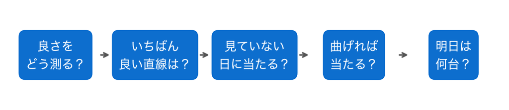

- 5つの小さな問いに順に答えて、式の実力と明日の台数にたどり着く

# 0. Colabと準備

## 式を作る前の準備

- 問いは決まった。式を作る前に、計算の準備をする
- 場所はColab、道具はライブラリ、データは731日の表

## Colab①：ノートを開く

0節 ① Colabの使い方●○○○○○

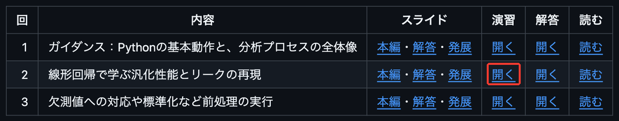

- 教材ページの表から、第2回の「演習」列の［開く］をクリック
- 開いたノートは、そのまま実行して使う。ドライブへのコピーは要らない

## Colabは道具がそろった環境

0節 ① Colabの使い方●●○○○○

- 主要な道具（パッケージ）が最初からそろった環境を、Googleが用意している
- ブラウザを開くだけで、全員が同じ環境になる
- 無料の範囲で使える。上限に達しても、勝手に課金されない

## Colab②：セルを実行する

0節 ① Colabの使い方●●●○○○

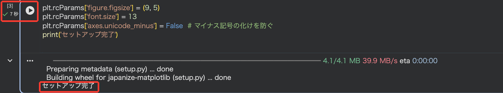

- コードのセルは、左の ▶ かShift + Enterで実行
- 結果がすぐ下に出て、終わると左に ✓ が付く
- 最初に「Googleが作成したものではありません」と出たら、［このまま実行］

## プログラムは上から下へ

0節 ① Colabの使い方●●●●○○

- セルの中は、上の行から順に実行される
- ノートも、上のセルから順に実行する。前のセルで作ったものを、後で使うから
- 迷ったら、いちばん上から実行し直す

## エラーはいちばん下の行を読む

0節 ① Colabの使い方●●●●●○

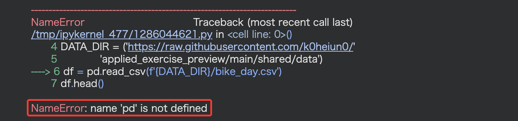

- NameError：上のセルを飛ばした
- ModuleNotFoundError：道具が入っていない／SyntaxError：打ち間違い

## セルは役割・入力・出力で読む

0節 ① Colabの使い方●●●●●●

- 各節で、まずお手本のセルを実行し、次にそのセルを少し変えて広げる
- セルは1行ずつより、役割・入力・出力のかたまりで読む

## お手本：道具を呼び出す

0節 ② 道具を呼ぶ●○○○○○

```python
import numpy as np
import pandas as pd
import matplotlib.pyplot as plt
from sklearn.linear_model import LinearRegression
from sklearn.model_selection import train_test_split
from sklearn.preprocessing import PolynomialFeatures
from sklearn.pipeline import Pipeline
```

- 役割：このノートで使う道具（ライブラリ）を呼び出す
- 入力：なし 出力：なし（終わるとセルの左に ✓ が付く）

## `import`は道具箱を持ってくる

0節 ② 道具を呼ぶ●●○○○○

```python
import pandas as pd
```

- 表を読む・図を描く機能は、Pythonの本体に入っていない
- ライブラリ（道具箱）を足して使う。`import`は、それを持ってくる命令
- `as pd`で、`pd`という短い呼び名で使えるようにする

## `from`は1つだけ取り出す

0節 ② 道具を呼ぶ●●●○○○

```python
from sklearn.linear_model import LinearRegression
```

- sklearnの道具箱の中から、`LinearRegression`だけを取り出す
- このあとは、`LinearRegression`の名前だけで呼べる

## 今日の4つの道具箱

0節 ② 道具を呼ぶ●●●●○○

| 道具箱 | コードでの名前 | 使いみち |
| --- | --- | --- |
| numpy | `np` | 数の並び（配列）をまとめて計算する |
| pandas | `pd` | 表を読み、列を選ぶ |
| matplotlib | `plt` | 図を描く |
| scikit-learn | `sklearn` | 回帰の式を作り、データを分ける |

## `!pip`は道具を取り寄せる

0節 ② 道具を呼ぶ●●●●●○

```python
# 日本語が図の中で □ になるのを防ぐ
!pip install -q japanize-matplotlib
```

- `!pip install`は、Colabに入っていない道具を取り寄せる命令
- `#`から行の終わりはコメント。Pythonは読み飛ばす、人のためのメモ
- このセルの`try:`から先は、日本語表示の保険。中身は読まなくてよい

## `print`は画面に出す

0節 ② 道具を呼ぶ●●●●●●

```python
print('セットアップ完了')
```

- かっこの中を、セルのすぐ下に表示する
- 「セットアップ完了」と出れば、このセルの最後まで動いた

## お手本：表を読み込む

0節 ③ 表を読む●○○○

```python
# 自転車シェアの日次データ（1日1行）を読み込む
# データはこのリポジトリから読み込む
DATA_DIR = ('https://raw.githubusercontent.com/k0heiun0/'
            'applied_exercise_preview/main/shared/data')
df = pd.read_csv(f'{DATA_DIR}/bike_day.csv')
df.head()
```

- 役割：CSVファイルの表を読み込み、先頭5行を見る
- 入力：データの置き場所とファイル名 出力：表`df`（このあと全部の節で使う）

## `df =`は名前にしまう

0節 ③ 表を読む●●○○

```python
df = pd.read_csv(f'{DATA_DIR}/bike_day.csv')
df.head()
```

- 右で読んだ表を、左の名前`df`にしまう。これが変数
- `pd.read_csv`は「pandasのread_csv」という関数。CSVファイルの表を読む
- `df.head()`のように`df.`に続けて書くのは、表が持つ機能（メソッド）

## dfは1枚の表

0節 ③ 表を読む●●●○

|  | instant | dteday | season | yr | temp | casual | registered | cnt |
| --- | --- | --- | --- | --- | --- | --- | --- | --- |
| 0 | 1 | 2011-01-01 | 1 | 0 | 0.344167 | 331 | 654 | 985 |
| 1 | 2 | 2011-01-02 | 1 | 0 | 0.363478 | 131 | 670 | 801 |
| 2 | 3 | 2011-01-03 | 1 | 0 | 0.196364 | 120 | 1229 | 1349 |
| 3 | 4 | 2011-01-04 | 1 | 0 | 0.200000 | 108 | 1454 | 1562 |
| 4 | 5 | 2011-01-05 | 1 | 0 | 0.226957 | 82 | 1518 | 1600 |

- 1行が1日、列がその日の項目。左端の0, 1, 2, …は行の番号
- pandasでは、この表をDataFrameと呼ぶ。`df`はその頭文字
- 列が16本あるので、スライドでは8本だけを見せる

## 列名が読みにくい

0節 ③ 表を読む●●●●

|  | instant | dteday | season | yr | temp | casual | registered | cnt |
| --- | --- | --- | --- | --- | --- | --- | --- | --- |
| 0 | 1 | 2011-01-01 | 1 | 0 | 0.344167 | 331 | 654 | 985 |
| 1 | 2 | 2011-01-02 | 1 | 0 | 0.363478 | 131 | 670 | 801 |
| 2 | 3 | 2011-01-03 | 1 | 0 | 0.196364 | 120 | 1229 | 1349 |
| 3 | 4 | 2011-01-04 | 1 | 0 | 0.200000 | 108 | 1454 | 1562 |
| 4 | 5 | 2011-01-05 | 1 | 0 | 0.226957 | 82 | 1518 | 1600 |

- season・yr・mnth・cnt……英語の略称で、何の列かすぐには読めない
- 前処理として、列名を日本語に付け替えてから使う

## お手本：列名を日本語にする

0節 ④ 列名を日本語に●○○

```python
ja_names = {'instant': '番号', 'dteday': '日付', 'season': '季節',
            'yr': '年', 'mnth': '月', 'holiday': '祝日',
            'weekday': '曜日', 'workingday': '平日',
            'weathersit': '天気', 'temp': '気温', 'atemp': '体感気温',
            'hum': '湿度', 'windspeed': '風速', 'casual': '一般客',
            'registered': '会員', 'cnt': '台数'}
df = df.rename(columns=ja_names)
df.head()
```

- 役割：英語の列名を日本語に付け替え、先頭5行を見る
- 入力：表`df` 出力：列名が日本語になった表`df`

## `{ }`は名前の対応表

0節 ④ 列名を日本語に●●○

```python
ja_names = {'instant': '番号', 'dteday': '日付', 'season': '季節',
```

- `{'元の名前': '新しい名前', ...}`と組を並べたもの。辞書と呼ぶ
- `rename(columns=ja_names)`で、この対応どおりに列名を付け替える
- 値は変わらない。変わるのは列名だけ

## 列名が日本語になった

0節 ④ 列名を日本語に●●●

|  | 番号 | 日付 | 季節 | 年 | 気温 | 一般客 | 会員 | 台数 |
| --- | --- | --- | --- | --- | --- | --- | --- | --- |
| 0 | 1 | 2011-01-01 | 1 | 0 | 0.344167 | 331 | 654 | 985 |
| 1 | 2 | 2011-01-02 | 1 | 0 | 0.363478 | 131 | 670 | 801 |
| 2 | 3 | 2011-01-03 | 1 | 0 | 0.196364 | 120 | 1229 | 1349 |
| 3 | 4 | 2011-01-04 | 1 | 0 | 0.200000 | 108 | 1454 | 1562 |
| 4 | 5 | 2011-01-05 | 1 | 0 | 0.226957 | 82 | 1518 | 1600 |

- ここから先は、季節・気温・台数といった日本語の名前で列を選ぶ

## やってみよう：0節

0節 ⑤ 確かめる●○

- 第2回のノートを開き、0節のセルを上から順に実行する
- 最後のセルの下に、列名が日本語の表が出ればよい

動画の人は、ここで一時停止。

## 答え合わせ：セットアップ完了

0節 ⑤ 確かめる●●

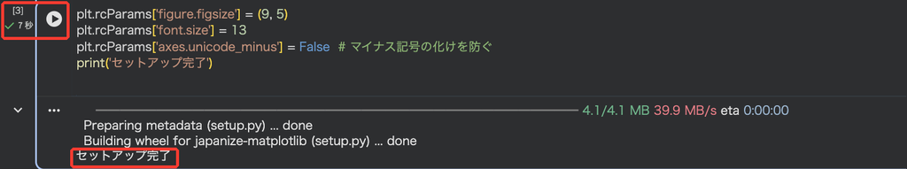

- 2つ目のセルの下に「セットアップ完了」、最後のセルの下に日本語の列名の表
- 赤いエラーが出たら、いちばん下の行を読み、上のセルから実行し直す

# 1. 列を数の並びとして取り出す

## まずは直線の良さの測り方から

- 直線の式は、1日の気温を入れて台数を出す。1日ずつの値が要る

## 列を番号付きの並びにする

1節 ① 配列にする●○○○○

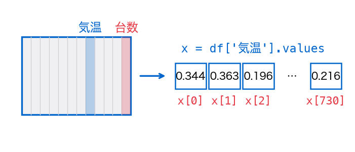

- 気温と台数の列を、番号で1日ずつ取り出せる形（配列）にする

## 表から列を1本選ぶ

1節 ① 配列にする●●○○○

```python
df['台数']        # 台数の列だけ
```

- 表から1つの列を取り出すには、`[ ]`に列名を入れる

## お手本：列を配列にする

1節 ① 配列にする●●●○○

```python
x = df['気温'].values     # 気温（731日ぶん）
y = df['台数'].values      # 台数（731日ぶん）
print(len(x))             # いくつ並んでいるか
print(x[0])               # 1日目の気温
print(y[0])               # 1日目の台数
```

- 役割：気温と台数を、数の並び（配列）として取り出す
- `len(x)`は、並んでいる数の個数。`print()`は0節で見たとおり、かっこの中を表示する

## 配列は番号で取り出す

1節 ① 配列にする●●●●○

```python
x = df['気温'].values     # 気温（731日ぶん）
print(x[0])               # 1日目の気温
print(y[0])               # 1日目の台数
```

- `.values`を付けると、列がnumpyの配列になる
- `x[0]`のように番号で1つずつ取り出せる。番号は0から数える

## 1日目は985台

1節 ① 配列にする●●●●●

```
731
0.344167
985
```

- 731個の数が並ぶ。1日目は気温0.344（約14.1℃）、台数985台

## やってみよう：1節

1節 ② 確かめる●

- 1節のお手本のセルを実行する
- ここまでと同じ数が出るか確かめる

動画の人は、ここで一時停止。

# 2. 1日目を直線で予測すると？

## 1日目の985台を直線で当てると？

- 1節で取り出した1日目を、直線の式で予測してみる

## 段の代わりに直線を

2節 ① 直線の式●○○○

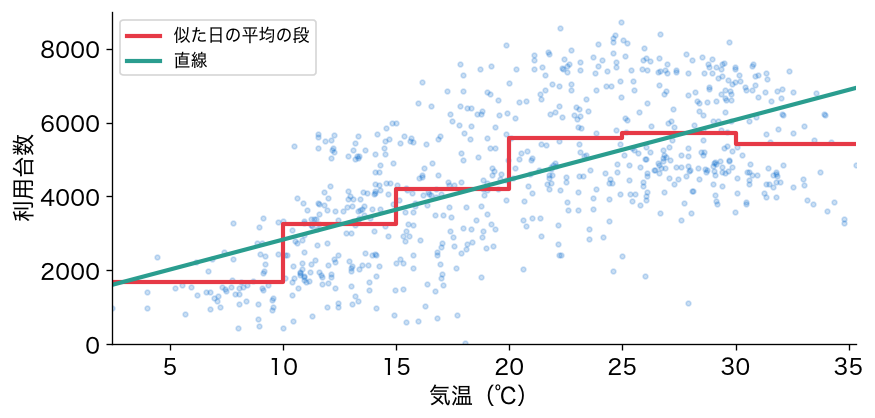

- 段の代わりに、1本の直線で答えたい。直線の式で当てることを、線形回帰と呼ぶ

## 直線の式

2節 ① 直線の式●●○○

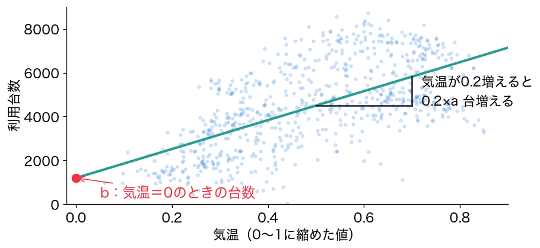

- 台数 ≈ a × 気温 + b。aは傾き、bは切片（気温が0のときの台数）

## 記号で書く

2節 ① 直線の式●●●○

$$\hat{y}_i = a\,x_i + b \qquad (i = 1, 2, \dots, 731)$$

- $x_i$は$i$日目の気温（0〜1に縮めた値）、$y_i$はその日の台数
- $\hat{y}_i$（ワイ・ハット）は、直線による予測。ハットは「予測」の印

## 気温の1は約41℃

2節 ① 直線の式●●●●

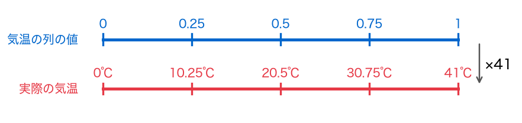

- $x_i = t_i / 41$（$t_i$は℃）。だから1℃あたりの増え方は$a/41$
- a=6600の直線なら、1℃で約160台ずつ上がる

## 直線は無数に引ける

2節 ② 良さの物差し●○○○○

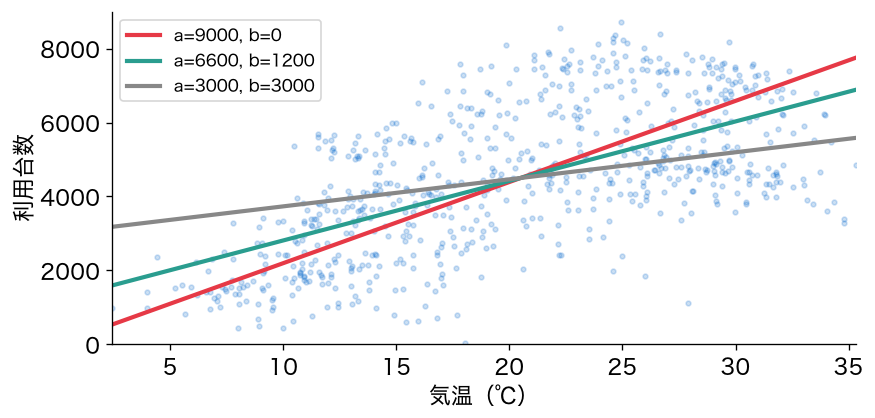

- aとbの組み合わせは、無数にある（aは気温に掛ける数）

## どれが「良い直線」？

2節 ② 良さの物差し●●○○○

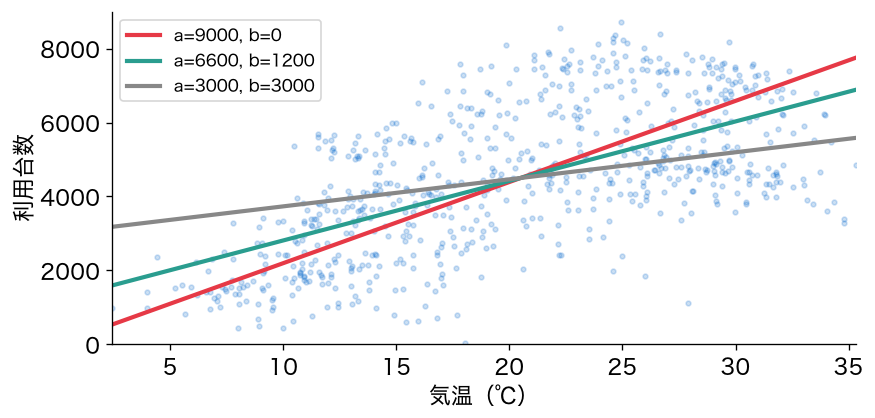

- 良さを測る物差しが要る。まず、1日目だけで考える

## 外れ ＝ 残差

2節 ② 良さの物差し●●●○○

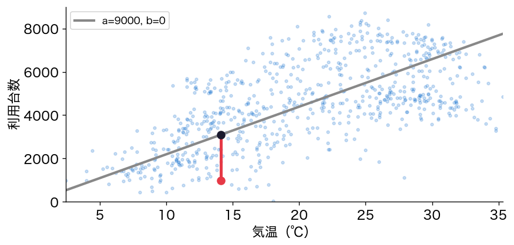

- 赤い縦線が、実際（赤い点）と予測（黒い点）のずれ $e_i = y_i - \hat{y}_i$。これを残差と呼ぶ

## なぜ二乗するのか

2節 ② 良さの物差し●●●●○

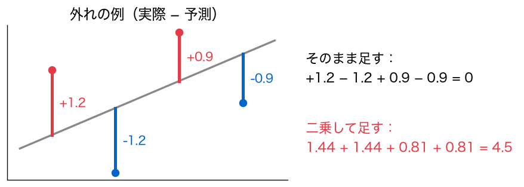

- そのまま足すと、プラスとマイナスが打ち消し合う。二乗すれば消えない

## 二乗のもう1つの良さ

2節 ② 良さの物差し●●●●●

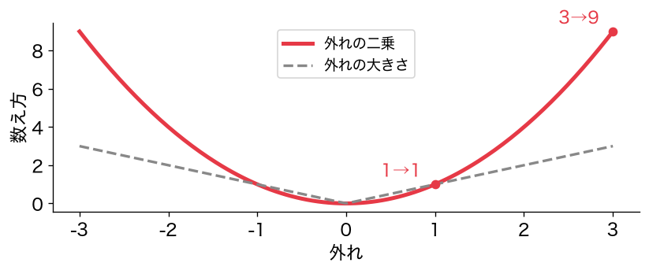

- 大きく外れた日ほど重く数える（1は1、3は9）。二乗の和はなめらかな谷になる

## お手本：1日目の予測と外れ

2節 ③ 1日目の外れ●○

```python
a = 9000
b = 0
pred = a * x[0] + b       # 1日目の予測
print(pred)
err = y[0] - pred         # 外れ（実際 − 予測）
print(err)
print(err ** 2)           # 外れの二乗
```

- 役割：a=9000・b=0の直線で1日目を予測し、外れを出す

## 予測3098台で外れ −2112台

2節 ③ 1日目の外れ●●

```
3097.503
-2112.503
4462668.925009001
```

- 予測 約3098台、実際985台。外れは −2112.5台、二乗は約446万

## TODO①：2日目と3日目も

2節 ④ 確かめる●○○○○

```python
# TODO: 上のセルをコピーして、[0] を [1]（2日目）と
#       [2]（3日目）に変えて表示する
...
```

- お手本の`[0]`を、`[1]`と`[2]`に変えるだけ

## TODOの書き方

2節 ④ 確かめる●●○○○

- TODOのセルの`...`を消して、そこに書く
- 何を書くかはセルの前の文章に、手がかりは「ヒント」のコメントにある
- お手本のコードをコピーして貼り付け、そこから書き換えると楽

## やってみよう：2節とTODO①

2節 ④ 確かめる●●●○○

- 2節のお手本のセルを実行し、同じ数が出るか確かめる
- TODO①：2日目と3日目の、予測・外れ・外れの二乗を出す

動画の人は、ここで一時停止。

## 答え合わせ：TODO①

2節 ④ 確かめる●●●●○

```
3271.302 -2470.302 6102391.9712040005
1767.276 -418.27600000000007 174954.81217600006
```

- 2日目の外れは −2470.3、3日目は −418.3

## 731日ぶん同じことを書く？

2節 ④ 確かめる●●●●●

- 1日ずつ書くのは、3日で大変
- 731日ぶんを、繰り返しで書きたい

# 3. 731日ぶんを足し上げる

## 731日の外れを1つの数に

- 直線の良さを、731日ぶんの外れで測る

## 二乗和を物差しにする

3節 ① for文で足し上げる●○○○○○

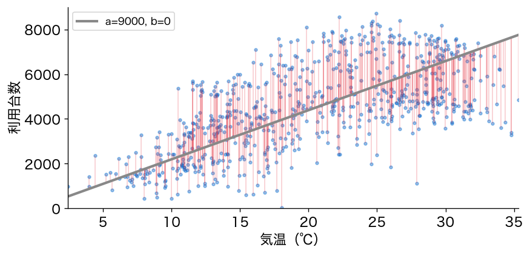

- 731本の縦線（外れ）を二乗して全部足した二乗和。小さいほどよい直線

## 二乗和を式で書く

3節 ① for文で足し上げる●●○○○○

$$S(a, b) = \sum_{i=1}^{731} \bigl(y_i - (a\,x_i + b)\bigr)^2$$

- $\sum$は、$i=1$から731までを足し上げる記号
- aとbを決めると、二乗和が1つに決まる。だから$S(a, b)$と書く

## お手本：for文で足し上げる

3節 ① for文で足し上げる●●●○○○

```python
total = 0
for i in range(len(x)):
    pred = a * x[i] + b                  # その日の予測
    total = total + (y[i] - pred) ** 2   # 外れの二乗を足す
print(total)
```

- 役割：731日ぶんの外れの二乗を、1日ずつ足し上げる

## for文の読み方

3節 ① for文で足し上げる●●●●○○

```python
for i in range(len(x)):
    pred = a * x[i] + b                  # その日の予測
```

- `i`を0, 1, 2, …, 730と変えながら、下の行を繰り返す
- 字下げ（行の頭のすきま）が、繰り返す範囲の目印

## total = total + …

3節 ① for文で足し上げる●●●●●○

```python
total = 0
for i in range(len(x)):
    pred = a * x[i] + b                  # その日の予測
    total = total + (y[i] - pred) ** 2   # 外れの二乗を足す
```

- 「いまの合計に足して、合計を更新する」という意味
- 最初に`total = 0`で、合計を空にしておく
- $\sum$の1項ずつを、`for`文で足している

## 二乗和は約18.0億

3節 ① for文で足し上げる●●●●●●

```
1798539709.665675
```

- a=9000・b=0の直線の二乗和は、約18.0億

## 変えてみる：numpyでまとめて

3節 ② numpyでまとめて●○○○

```python
residual = y - (a * x + b)       # 731日ぶんの外れを、まとめて
print(residual[:3])              # 最初の3日ぶん
print((residual ** 2).sum())     # 二乗して、全部足す
```

- numpyの配列は、`for`文なしでまとめて計算できる
- `.sum()`は、全部を足すメソッド

## `[:3]`は最初の3つ

3節 ② numpyでまとめて●●○○

```python
print(residual[:3])              # 最初の3日ぶん
```

- `[:3]`は、番号0・1・2の3つを取り出す（スライス）
- `[始め:終わり]`の形。始めを省くと0から。終わりの番号は含まない

## numpyでも同じ二乗和

3節 ② numpyでまとめて●●●○

```
[-2112.503 -2470.302  -418.276]
1798539709.665673
```

- 最初の3日は、2節とTODO①の値そのもの。二乗和も一致
- `for`文で書いたことを、numpyは1行でやっていた

## 実務ではforで足し上げない

3節 ② numpyでまとめて●●●●

- 実務では、numpyの1行で足す。速く、書き間違いも少ない
- `for`文で書いたのは、$\sum$の1項ずつを目で見るため

## やってみよう：3節

3節 ③ 確かめる●

- 3節のお手本と「変えてみる」のセルを実行する
- 2つの二乗和が同じになるか確かめる

動画の人は、ここで一時停止。

# 4. いちばん良いaとbは？

## いちばん良い直線は？

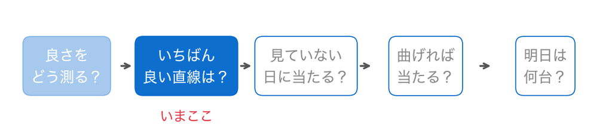

- 二乗和がいちばん小さい直線を探す

## まずはaだけを動かす

4節 ① aだけを動かす●○○○○○○○

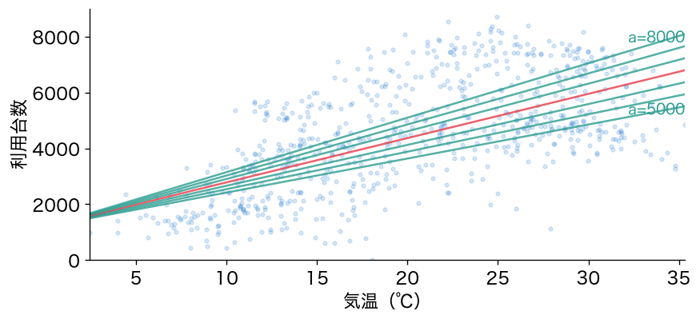

- bを1200に固定し、aを5000から8000まで順に試して、二乗和の最小を覚える

## お手本：aを100ずつ試す

4節 ① aだけを動かす●●○○○○○○

```python
best_a = None
best_sse = None
for a in range(5000, 8001, 100):              # 5000, 5100, …, 8000
    s = ((y - (a * x + 1200)) ** 2).sum()     # この a の二乗和
    if best_sse is None or s < best_sse:      # 小さければ覚え直す
        best_a = a
        best_sse = s
print(best_a, best_sse)
```

- 役割：bを1200に固定し、aを100ずつ変えて、二乗和が最小のaを探す

## rangeの3つの数

4節 ① aだけを動かす●●●○○○○○

```python
for a in range(5000, 5301, 100):
    print(a)          # 5000, 5100, 5200, 5300 と表示される
```

- `range(始め, 終わり, 刻み)`：始めから、刻みずつ増やす
- 終わりの数は含まない。8000まで入れたいので、8001と書く

## if文の読み方

4節 ① aだけを動かす●●●●○○○○

```python
    if best_sse is None or s < best_sse:      # 小さければ覚え直す
        best_a = a
        best_sse = s
```

- 条件が成り立つときだけ、下の字下げした行を実行する
- 「これまでの最小より小さければ、覚え直す」

## 1回目は必ず覚える

4節 ① aだけを動かす●●●●●○○○

```python
    if best_sse is None or s < best_sse:      # 小さければ覚え直す
```

- `None`は「まだ空」の印。最初は、覚えている最小がない
- `A or B`は「AまたはB」。1回目は`best_sse is None`で成り立つ
- 2回目からは、`s < best_sse`で決まる

## a=6700で最小

4節 ① aだけを動かす●●●●●●○○

```
6700 1661091384.2666712
```

- a=6700のとき、二乗和が最小

## 二乗和を図にすると？

4節 ① aだけを動かす●●●●●●●○

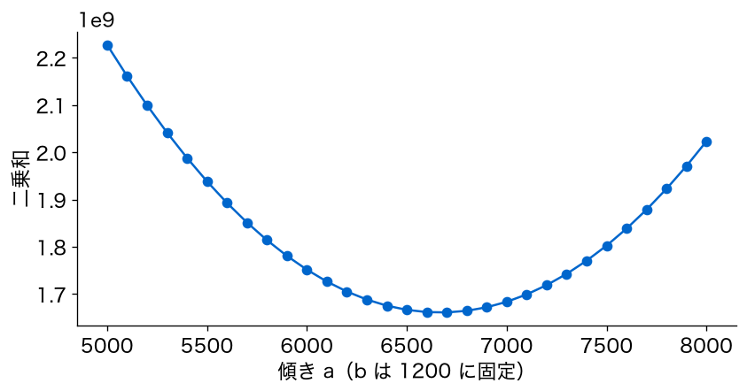

- 横がa、縦がそのaの二乗和

## 谷底は1つだけ

4節 ① aだけを動かす●●●●●●●●

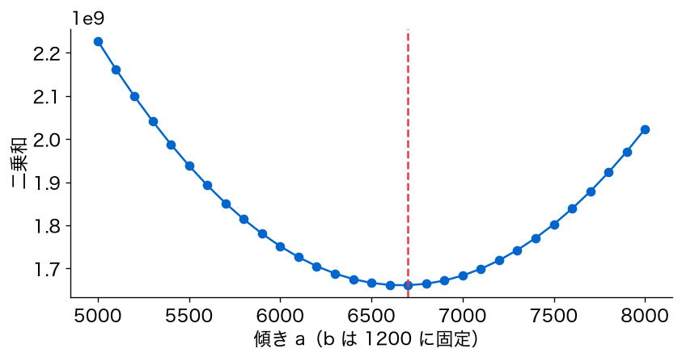

- U字の谷底が、いちばん良いa（点線の6700）

## bも動かすと格子になる

4節 ② bも動かす●○○○○

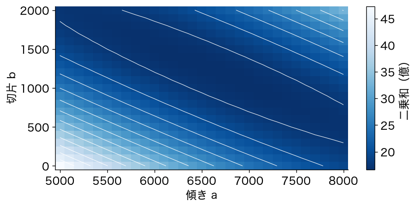

- aとbの組み合わせ1つが、格子の1点。色が濃いほど二乗和が小さい

## 変えてみる：bも動かす

4節 ② bも動かす●●○○○

```python
best = None
for a in range(5000, 8001, 100):
    for b in range(0, 2001, 100):          # b も動かす
        s = ((y - (a * x + b)) ** 2).sum()
        if best is None or s < best[2]:
            best = (a, b, s)
print(best)
```

- `for`文の中に`for`文。aとbのすべての組み合わせを試す

## bestに3つを覚える

4節 ② bも動かす●●●○○

```python
            best = (a, b, s)
```

- (a, b, 二乗和) の3つを、まとめて覚える
- `best[2]`は3つ目、つまり二乗和（番号は0から）

## 651通りでa=6700・b=1200

4節 ② bも動かす●●●●○

```
(6700, 1200, np.float64(1661091384.2666712))
```

- 31×21 ＝ 651通りを試して、a=6700・b=1200

## 格子の谷底

4節 ② bも動かす●●●●●

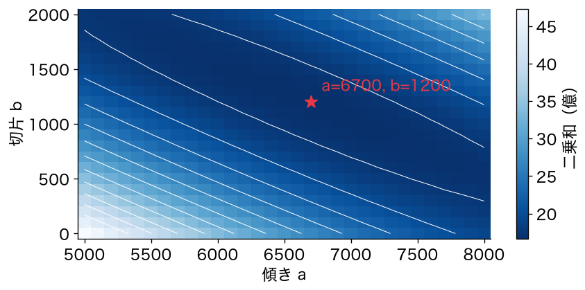

- 星印が、651通りの中で二乗和がいちばん小さい点

## TODO②：範囲を狭めて細かく

4節 ③ 確かめる●○○

```python
# TODO: 上のセルをコピーして、a を range(6400, 6801, 10)、
#       b を range(1000, 1401, 10) にする
...
```

- 変えるのは、`range`の中の数だけ

## やってみよう：4節とTODO②

4節 ③ 確かめる●●○

- 4節のお手本と「変えてみる」のセルを実行し、同じ結果を確かめる
- TODO②：範囲を狭め、10ずつ試す

動画の人は、ここで一時停止。

## 答え合わせ：TODO②

4節 ③ 確かめる●●●

```
(6650, 1210, np.float64(1660848919.0966713))
```

- 10ずつなら、a=6650・b=1210。二乗和は少し小さくなった